# Capstone Project Draft 1

Ryan Willett

Import required packages

```r
library(dplyr)
library(tidyr)
library(rvest)
library(readr)
library(RSelenium)
library(XML)
library(ggplot2)
library(dendextend)
setwd("~/Documents/GitHub/IntroDataScience_capstone")
```

```r
#ACTION ITEMS TO BUILD INTO THE CODE
###Column loop function to iterate through genes.
###Generalizable means to scrape the chromosomal location and GO categories for every gene.
```

Import the data and labels into two data sets.

```r
cancer_data <- read.csv("data.csv")
cancer_labels <- read.csv("labels.csv")
```

We must assign each case and the type of cancer that it is with the gene expression data.

```r
cancer_join <- left_join(cancer_data, cancer_labels, by = "X")
```

Now that we have each analyzed tumor labeled with the proper tumor type and each analyzed gene with the clear gene name.

### Use hierarchical clustering to determine if there are relationships between the different tumor groups on the basis of gene expression.

```r
#Attempt at a hierarchical analysis.
#Promisingly, there do seem to be 5 large subdivisions of the dendrogram. Do they correspond to the tumor classifications?
d <- dist(as.matrix(cancer_data))
```

```
NAs introduced by coercion
```

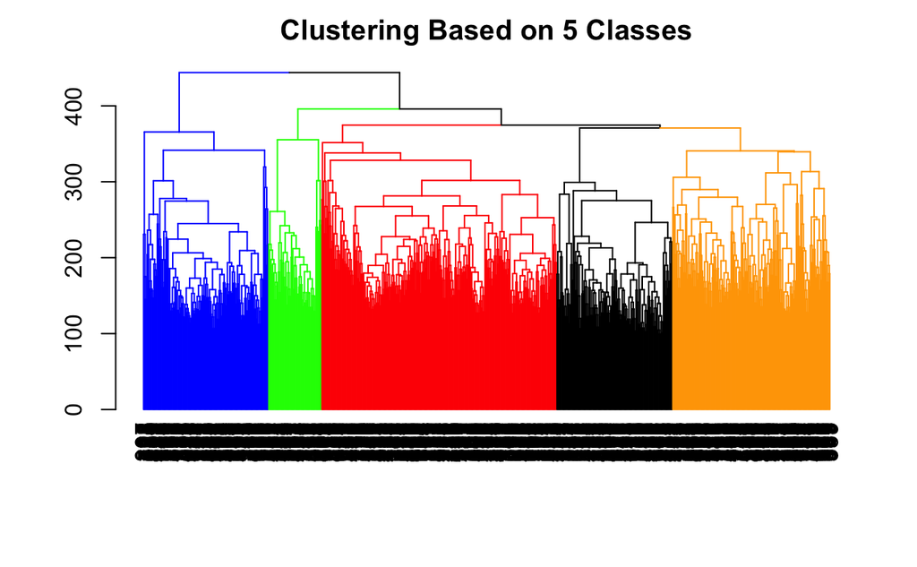

```r
hc <- hclust(d)
hc <- as.dendrogram(hc)
#Plot the data
#cols_branches <- c("blue", "green", "red", "black", "orange")
dend <- color_branches(hc, k=5, col = c("blue", "green", "red", "black", "orange"))
plot(dend, main = "Clustering Based on 5 Classes")
```

```r
#Select out clusters based on 5 classes (because we have 5 tumor types). Bind these groups information to the original dataset
groups <- cutree(hc, k=5)
cancer_join <- cbind(cancer_join, groups)
#Selecting out the different tumor classifications based on the clustering group.
hc1 <- subset(cancer_join$Class, groups==1)
hc2 <- subset(cancer_join$Class, groups==2)
hc3 <- subset(cancer_join$Class, groups==3)
hc4 <- subset(cancer_join$Class, groups==4)
hc5 <- subset(cancer_join$Class, groups==5)
subtype_freq <- data.frame(table(hc1), table(hc2), table(hc3), table(hc4), table(hc5))
subtype_freq
```

| hc1 | Freq | hc2 | Freq.1 | hc3 | Freq.2 | hc4 | Freq.3 | hc5 | Freq.4 |
| --- | --- | --- | --- | --- | --- | --- | --- | --- | --- |
| BRCA | 0 | BRCA | 22 | BRCA | 271 | BRCA | 0 | BRCA | 7 |
| COAD | 0 | COAD | 23 | COAD | 0 | COAD | 0 | COAD | 55 |
| KIRC | 0 | KIRC | 0 | KIRC | 0 | KIRC | 146 | KIRC | 0 |
| LUAD | 0 | LUAD | 139 | LUAD | 2 | LUAD | 0 | LUAD | 0 |
| PRAD | 135 | PRAD | 0 | PRAD | 1 | PRAD | 0 | PRAD | 0 |

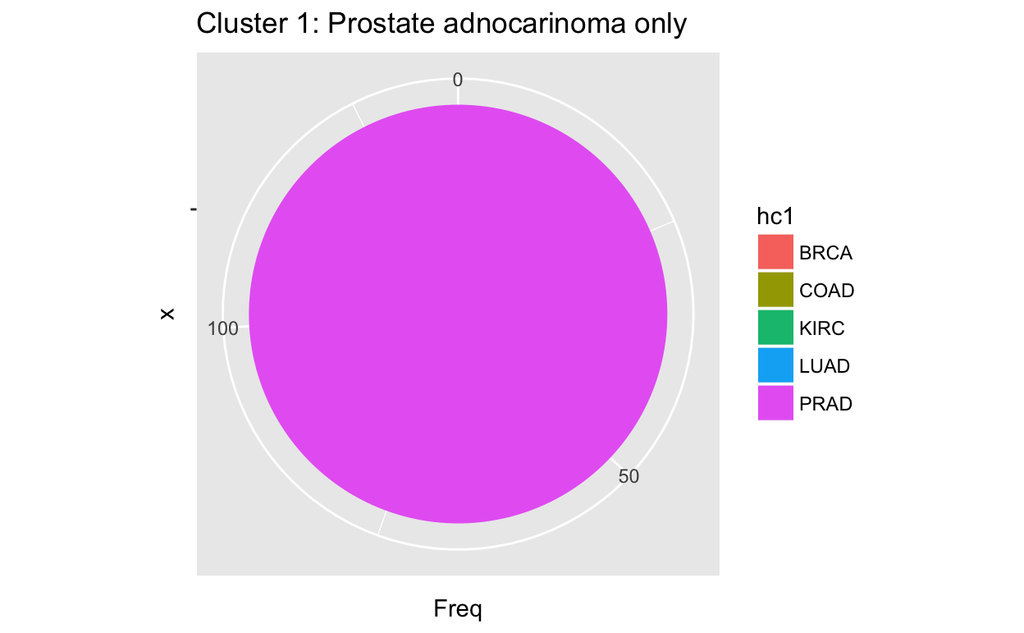

```r
cancer_pie1 <- ggplot(subtype_freq, aes(x="", y=Freq, fill = hc1)) + geom_bar(width = 1, stat = "identity") + coord_polar(theta = "y") + labs(title = "Cluster 1: Prostate adnocarinoma only")
cancer_pie1
```

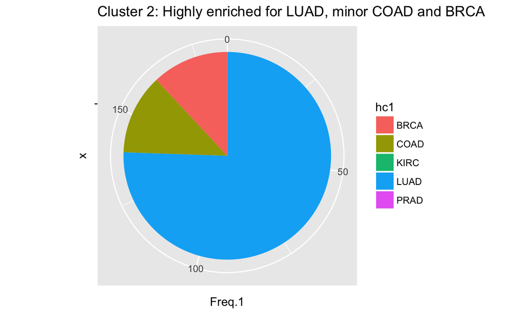

```r
cancer_pie2 <- ggplot(subtype_freq, aes(x="", y=Freq.1, fill = hc1)) + geom_bar(width = 1, stat = "identity") + coord_polar(theta = "y") + labs(title = "Cluster 2: Highly enriched for LUAD, minor COAD and BRCA")
cancer_pie2
```

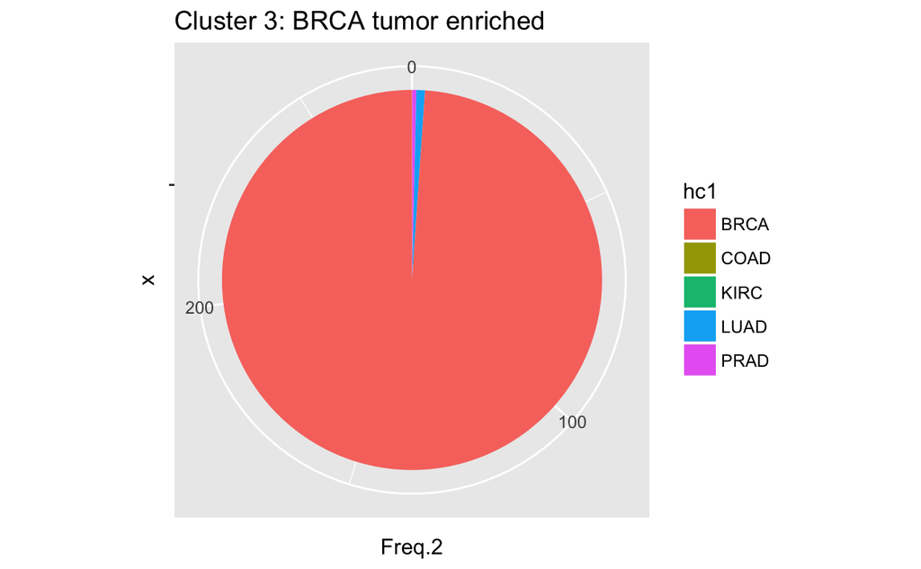

```r
cancer_pie3 <- ggplot(subtype_freq, aes(x="", y=Freq.2, fill = hc1)) + geom_bar(width = 1, stat = "identity") + coord_polar(theta = "y") + labs(title = "Cluster 3: BRCA tumor enriched")
cancer_pie3
```

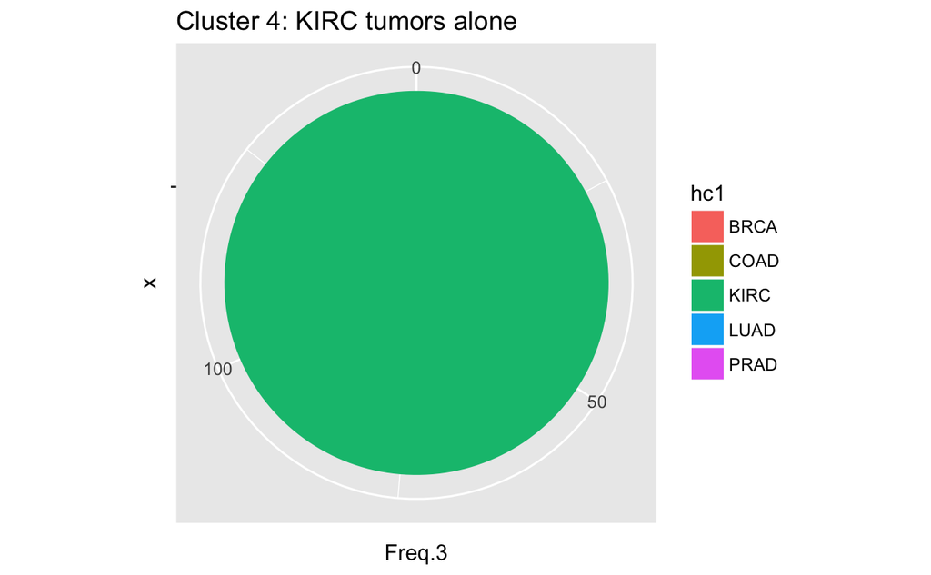

```r
cancer_pie4 <- ggplot(subtype_freq, aes(x="", y=Freq.3, fill = hc1)) + geom_bar(width = 1, stat = "identity") + coord_polar(theta = "y") + labs(title = "Cluster 4: KIRC tumors alone")
cancer_pie4
```

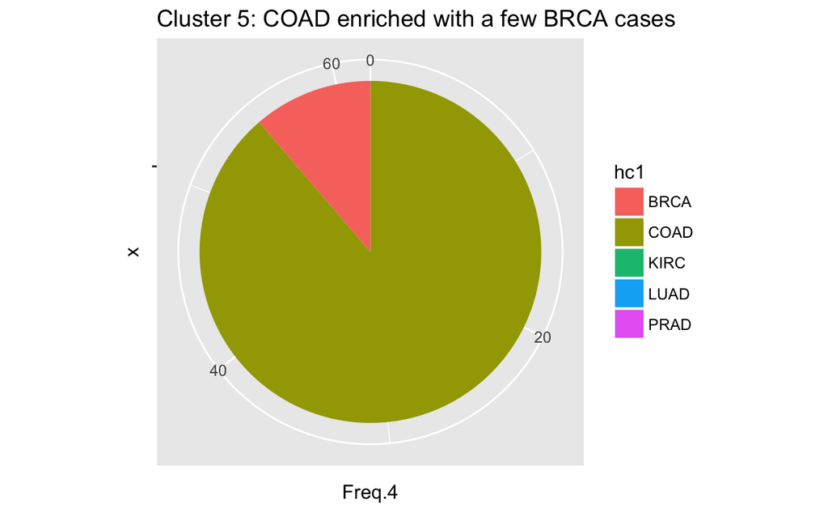

```r
cancer_pie5 <- ggplot(subtype_freq, aes(x="", y=Freq.4, fill = hc1)) + geom_bar(width = 1, stat = "identity") + coord_polar(theta = "y") + labs(title = "Cluster 5: COAD enriched with a few BRCA cases")
cancer_pie5
```

```r
#Create loops method that quantifies each incidence of each tumor type in the cluster group.
```

The minority tumor types in 2, 3, and 5 can be explained by a number of reasons. * These tumor types are misdiagnosed. * The majority and minority tumor types in the cluster arose from a similar cell-of-origin that is present in both tissues (e.g. similar cell type present in both breast and colon). * The minority tumor type may be metastasized tumors from other primary sites (e.g. breast cancer metastasized to colon in the example of cluster 5). * The mutagenic etiology of the tumor genetically resemble each other due to the type of tumor produced (e.g. similarities in colon and lung adenocarcinoma tumors in cluster 2 are due to them both being adenocarcinoma tumors. Interestingly the prostate adenocarcinoma are very distinct from colon and lung).

### Calculate summary dataset of tumor class groups

```r
#Building out a stub for a loop function to iterate over columns of data table "cancer_join" (gene_#)
small_gset <- c("gene_18530", "gene_11402", "gene_1589", "gene_7072", "gene_9212", "gene_53")
small_gset <- t(small_gset) #Convert single columns to single row
for(i in 1:ncol(small_gset)){print(small_gset[,i])} #Loop across the row.
```

```
[1] "gene_18530"
[1] "gene_11402"
[1] "gene_1589"
[1] "gene_7072"
[1] "gene_9212"
[1] "gene_53"
```

Calculate the mean and standard deviation for a sample set of genes.

```r
#CODE BLOCK IS TEMPORARILY NON-FUNCTIONAL AS I BUILD OUT MEAN/SD TO LOOP THROUGH ALL GENES
cancer_sample <- cancer_join %>% group_by(Class) %>%
    summarise() {
```

```
Error: unexpected '{' in:
"cancer_sample <- cancer_join %>% group_by(Class) %>%
    summarise() {"
```

### Do any of these show statistically significant differences across tumor types according to ANOVA?

```r
anova_TP53 <- aov(gene_18530 ~ Class, data = cancer_join)

anova_MYC <- aov(gene_11402 ~ Class, data = cancer_join)

anova_BRCA1 <- aov(gene_1589 ~ Class, data = cancer_join)

anova_BRCA2 <- aov(gene_1590 ~ Class, data = cancer_join)

anova_GLI1 <- aov(gene_7072 ~ Class, data = cancer_join)

anova_KRAS <- aov(gene_9214 ~ Class, data = cancer_join)

anova_53 <- aov(gene_53 ~ Class, data = cancer_join)

summary(anova_TP53)
summary(anova_MYC)
summary(anova_BRCA1)
summary(anova_BRCA2)
summary(anova_GLI1)
summary(anova_KRAS)
summary(anova_53)
```

[output not shown]

```r
tuk_TP53 <- TukeyHSD(anova_TP53)
tuk_MYC <- TukeyHSD(anova_MYC)
tuk_BRCA1 <- TukeyHSD(anova_BRCA1)
tuk_BRCA2 <- TukeyHSD(anova_BRCA2)
tuk_KRAS <- TukeyHSD(anova_KRAS)
tuk_gene53 <- TukeyHSD(anova_53)

tuk_TP53
tuk_MYC
tuk_BRCA1
tuk_BRCA2
tuk_KRAS
tuk_gene53
```

[output not shown]

```r
#Retain the 'Class' and 'p adj' columns from the Tukey post doc results (tuk_*), step through the p adj variables and convert to dummy variables if they are signficant to a CI of 0.01.

#WORK IN PROGRESS. This blocks is functional for the gene set. Loop needs to be written to apply this method to all genes.

tuk_TP53 <- tuk_TP53$Class[,4]
tuk_TP53 <- ifelse(tuk_TP53 <= 0.01, 1, 0)

tuk_MYC <- as.numeric(tuk_MYC$Class[,4])
tuk_MYC <- ifelse(tuk_MYC <= 0.01, 1, 0)

tuk_BRCA1 <- as.numeric(tuk_BRCA1$Class[,4])
tuk_BRCA1 <- ifelse(tuk_BRCA1 <= 0.01, 1, 0)

tuk_BRCA2 <- as.numeric(tuk_BRCA2$Class[,4])
tuk_BRCA2 <- ifelse(tuk_BRCA2 <= 0.01, 1, 0)

tuk_KRAS <- as.numeric(tuk_KRAS$Class[,4])
tuk_KRAS <- ifelse(tuk_KRAS <= 0.01, 1, 0)

tuk_gene53 <- as.numeric(tuk_gene53$Class[,4])
tuk_gene53 <- ifelse(tuk_gene53 <= 0.01, 1, 0)

tuk_pvals <- data.frame(tuk_TP53, tuk_MYC, tuk_BRCA1, tuk_BRCA2, tuk_KRAS, tuk_gene53)

#Transpose the vector so the genes are in the rows and the Tukey p-value comparisons are in the columns.
tuk_pvals <- t(tuk_pvals)
```

Genes with statistically significant difference in expression level between tumors by ANOVA will be assigned a dummy variable in the gene_codes dataframe.

As a point of comparison…

Here is the blot for expression level of TP53 in the tumors

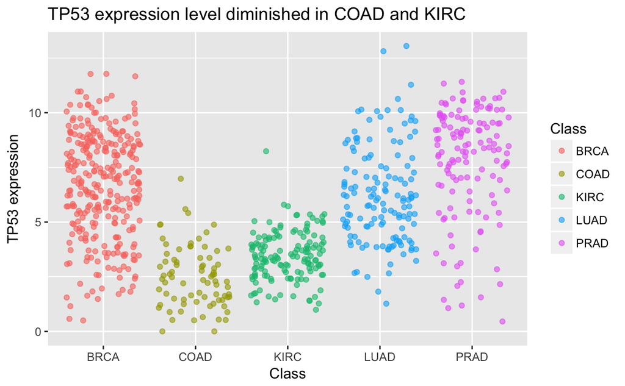

```r
ggplot(cancer_join, aes(x = Class, y = gene_18530, col = Class)) +
  geom_jitter(alpha = 0.6) +
  ylab("TP53 expression") +
  labs(title = "TP53 expression level diminished in COAD and KIRC")
```

There is a clear downregulation evident in the levels of TP53 expression in COAD and KIRC.

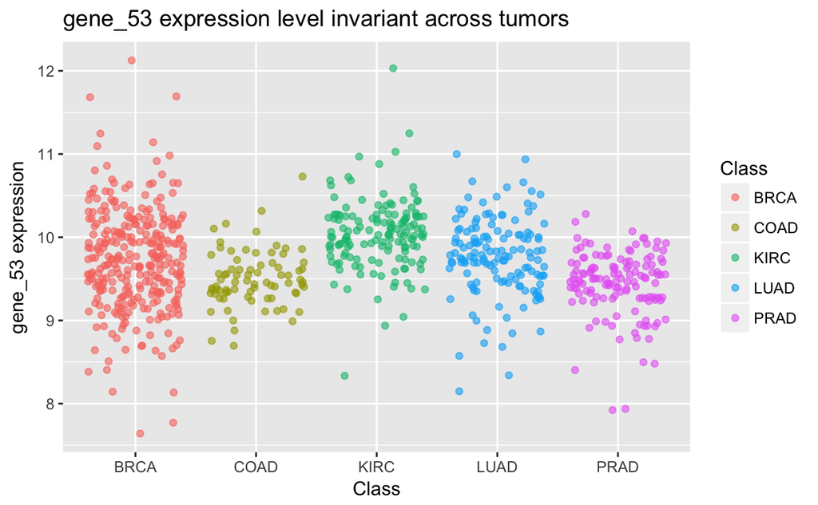

```r
ggplot(cancer_join, aes(x = Class, y = gene_53, col = Class)) + geom_jitter(alpha = 0.6) +
  ylab("gene_53 expression") +
  labs(title = "gene_53 expression level invariant across tumors")
```

The ANOVA results should reflect this, so need to figure out in the next week what is wrong.

### Generation of the gene_codes dataset

Import the unc.edu_PANCAN_IlluminaGA_RNASeqV2.geneExp from the Synapse repository to get the gene name and gene ID for all 20531 genes. They are in the first column labeled “gene_id” and are in the format “gene name | gene id”. Strip out this column, separate the gene name and gene ID into separate columns, and build another column with the dummy variable names corresponding to the probes in “data.csv”. Ultimately, additional columns will be appended onto the dataset as the webscraping data methods become functional.

This code block does not have to be run after “gene_information.csv” has been generated.

```r
#Imports in only a couple columns from PANCAN_RNAseq.tsv .
#This is done because the table takes a VERY long time to load and we only need the first column of information.
gene_codes <- read.table(pipe("cut -f1,5 PANCAN_RNAseq.tsv"))
```

```
cut: PANCAN_RNAseq.tsv: No such file or directory
Error in read.table(pipe("cut -f1,5 PANCAN_RNAseq.tsv")) :
  no lines available in input
```

```r
#Write out the new dataset as a CSV file, because it is more convenient to load than the original .tsv file
write.csv(gene_codes, file = "gene_information.csv", row.names = FALSE)
```

```r
gene_codes <- read.csv("gene_information.csv")
```

### Prototype for enriching data set with web scraped data

This section is to prototype building up additional data to the dataset for a small set of genes

```r
cancer_subset <- gene_codes[50:55, ]
cancer_subset
```

|  | gene_name | gene_ID |
| --- | --- | --- |
| 50 | AANAT | 15 |
| 51 | AARS2 | 57505 |
| 52 | AARSD1 | 80755 |
| 53 | AARS | 16 |
| 54 | AASDHPPT | 60496 |
| 55 | AASDH | 132949 |

```r
genbank <- "https://www.ncbi.nlm.nih.gov/gene/"
#Loop function to step through "gene_ID"" of the data set to scrape data into additional columns. Right now it only prints the urls to scrape. Once the scraping methods have been written, they will be entered in the loop and the data collected.
scrape <- function(x) {
  url <- paste(genbank,x, sep = "")
}
lapply(cancer_subset$gene_ID, scrape)
```

```
[[1]]
[1] "https://www.ncbi.nlm.nih.gov/gene/15"

[[2]]
[1] "https://www.ncbi.nlm.nih.gov/gene/57505"

[[3]]
[1] "https://www.ncbi.nlm.nih.gov/gene/80755"

[[4]]
[1] "https://www.ncbi.nlm.nih.gov/gene/16"

[[5]]
[1] "https://www.ncbi.nlm.nih.gov/gene/60496"

[[6]]
[1] "https://www.ncbi.nlm.nih.gov/gene/132949"
```

### Additional information we can glean through webscraping:

- Chromosome position
- amino acid sequence of the protein
- nucleotide sequence of the ORF.
- Definition.
- Are structure solved?
- GO compartment/process/component/function
- Jensen-TM (text mined tissue expression data)

### Scraping prototypes

From what I can tell, the rvest package is effective at scraping static webpages, but several of the repositories that I am trying to scrape from return with the “character(0)” complaint. I will need to learn how to use Phantom.js or RSelenium to scrape dynamic pages to get this information.

```r
#Web scraping strategy using the rvest package.
testing <- read_html("https://www.ncbi.nlm.nih.gov/gene/15")

#chromosomal location - Working
#gene_location <- testing %>% html_nodes(".dl-chr-info span") %>% html_text()
#gene_location
```

[output not shown]